# act_report

**Twitter API**

In this post I would like to demonstrate how we can gather and visualize data from the popular twitter account “We rate Dogs” (https://twitter.com/dog_rates). Twitter has a very useful API that makes all sorts of data available to developers. All it takes is a signup and a quick explanation as to why you’re interested in collecting data. It’s possible to either setup a listener to gather data or access archived data. This is a very useful tool with a broad range of applications.

**How to get started**

Signup for the twitter api here https://developer.twitter.com/en/docs

**Libraries you’ll need**

- SQLite3 (*Optional, however very useful for querying*)
- Pandas (*very robust library for data analysis)*
- Numpy (*library for scientific computing*)
- Matplotlib (*library for robust plotting visualizations*)
- Seaborn (*statistical data visualization*)
- Datetime (*Datatime library for python*)
- Json (*Minimal, readable format for structuring data*)
- OS (*Provides function for interacting with the operating system*)
- Requests (*Library used to handle HTTP requests*)
- String (*Library used to handle string datatypes*)
- Tweepy (*Library used to interact with the Twitter API*)

These packages can be installed using PIP from your console. I will not get into the wrangling and cleaning portion in this post. It is merely a demonstration of potential in a simple form. If you would like to thoroughly observe the methods for wrangling, analysis and cleaning please view “wrangle_act.ipynb”.

### We have all this data now what?

What are the most popular dog names from this interactive twitter account?

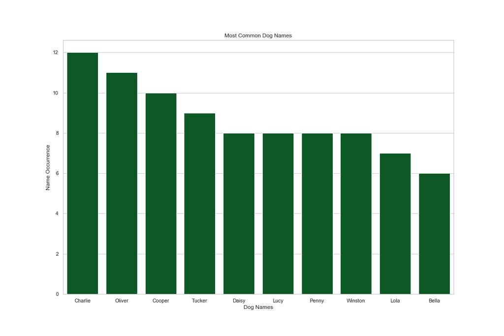

```python
from IPython.display import Image
Image(filename='popular_dog_names.png')
```

We can also represent this visually using a word cloud.

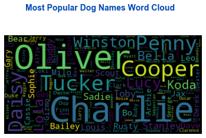

```python
Image(filename='word_cloud.png')
```

Which dogs have the highest retweets?

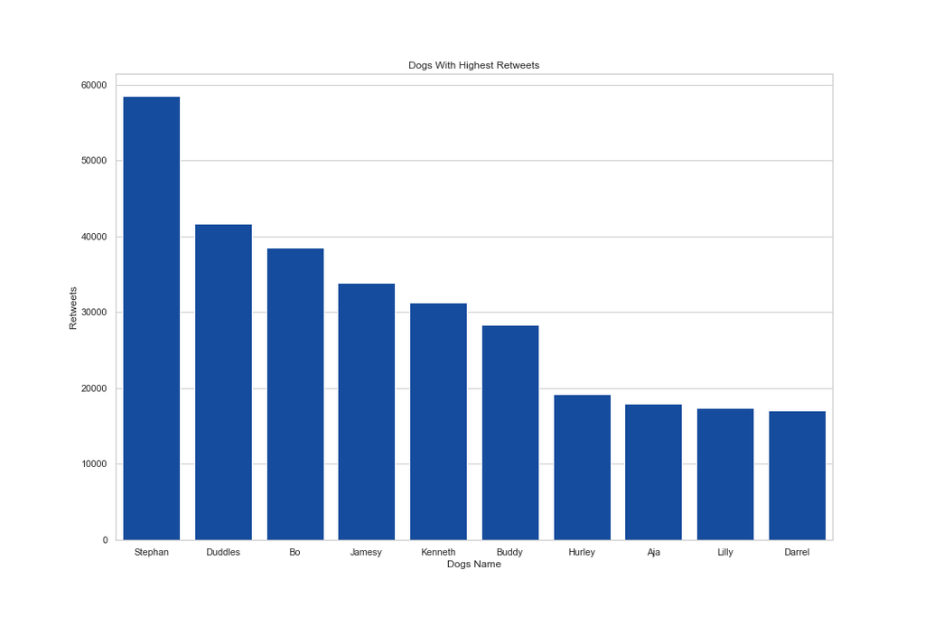

```python
Image(filename='retweets.png')
```

What are our retweets over time are people interacting?

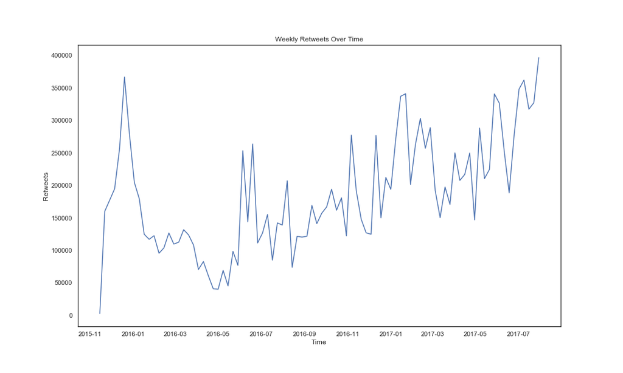

```python
Image(filename='weekly_retweets.png')
```

### Conclusion:

Through the visualization process we can determine the value of organizing our data in a meaningful way. If done with precision and careful analysis we can gain valuable insight into our user base, creating a more robust experience. We are always limited to the data however twitter's API is invaluable for marketing and research initiatives. We can apply these methods across multiple industries. The information we gather can also be utilized to gain an understanding of society.